# DATA ANALYTICS PROJECT ON HR DATA-SET OF IBM COMPANY(USA)

## GRAPHICAL REPRESENTATION

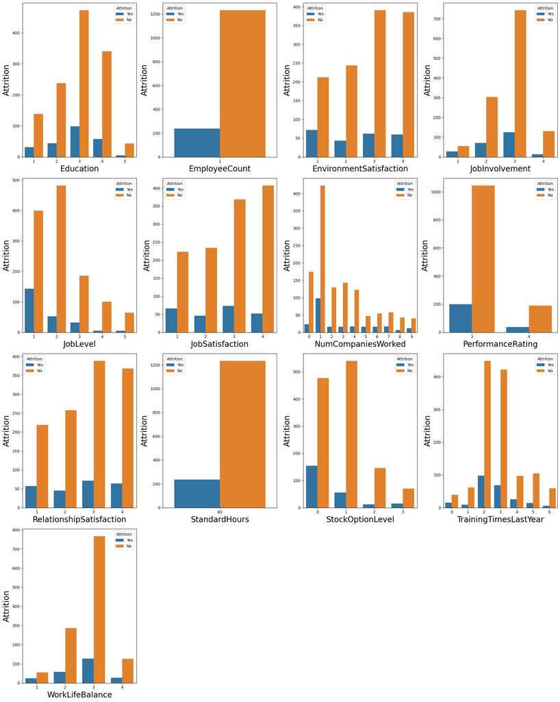

```python
plt.figure(figsize=(20,25), facecolor="white")
plotnumber = 1

for column in df2:
    if plotnumber<=16:
        ax = plt.subplot(4,4, plotnumber)
        sns.countplot(x=df2[column].dropna(axis=0)
                        ,hue=df.Attrition)
        plt.xlabel(column,fontsize=20)
        plt.ylabel("Attrition", fontsize=20)
    plotnumber+=1
plt.tight_layout()
```

1. IMPACT OF ENVIRONMENT AND JOB SATISFACTION ON ATTRITION

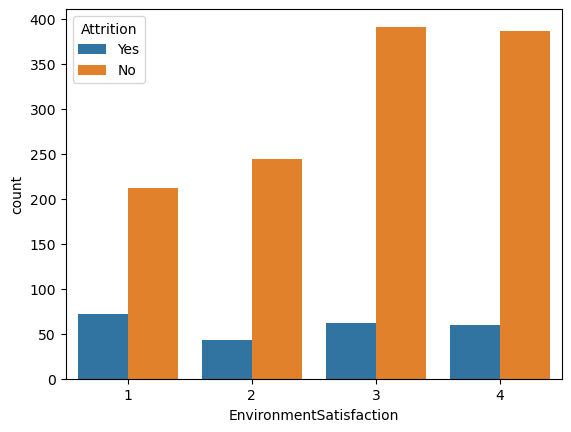

```python
sns.countplot(x=df.EnvironmentSatisfaction, hue=df.Attrition)
plt.show()
```

- Increase in rate of Environment as well as job satisfaction gives rise to increase in Attrition "No" (means not willing to quit).

2.HOW JOB LEVEL IS AFFECTING ATTRITION

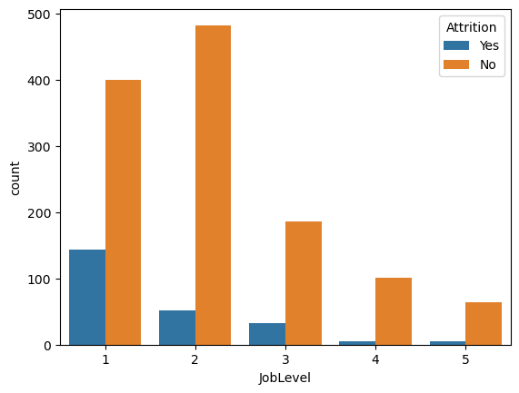

```python
sns.countplot(x=df.JobLevel, hue=df.Attrition)
plt.show()
```

- Increase in job level, Decrease in chances of leaving the company for employees.
3. JOB INVOLVEMENT IMPACTING ON ATTRITION

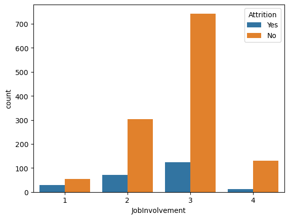

```python
sns.countplot(x=df.JobInvolvement, hue=df.Attrition)
plt.show()
```

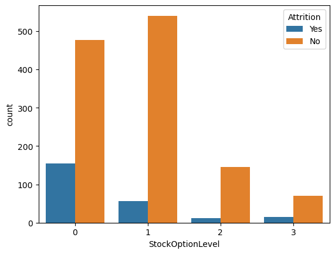

```python
sns.countplot(x=df.StockOptionLevel, hue=df.Attrition)
plt.show()
```

- For the employees who are not having stock option are likely to quit.
5. PERFORMANCE RATING AND ATTRITION

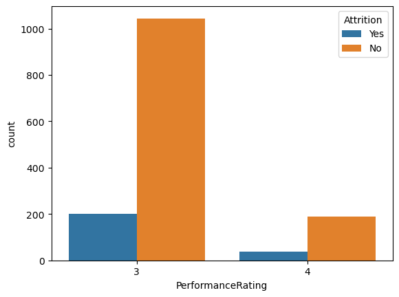

```python
sns.countplot(x=df.PerformanceRating, hue=df.Attrition)
plt.show()
```